# Отчёт по лабораторной работе №7

Адресация IPv4 и IPv6. Настройка DHCP

Элсаиед Адел

Российский университет дружбы народов, Москва, Россия

22 января 2026

# Цель работы

## Цель лабораторной работы

Получение навыков настройки службы **DHCP** на сетевом оборудовании для распределения адресов **IPv4** и **IPv6**, а также анализ обмена сообщениями DHCP/DHCPv6 в **Wireshark**.

# Ход выполнения работы

## Топология и подготовка стенда

- Среда моделирования: **GNS3**
- Устройства: `PC1-elsaiedadel` → `elsaiedadel-sw-01` → `elsaiedadel-gw-01 (VyOS)`
- Сегмент: `10.0.0.0/24`
- Задача: раздача адресов `10.0.0.2–10.0.0.253`

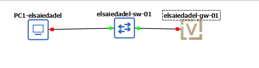

Топология моделируемой сети (IPv4)

## Первичная настройка VyOS

- Установка системы на виртуальный диск
- Настройка:
  - host-name: `elsaiedadel-gw-01`
  - domain-name: `elsaiedadel.net`
  - создание пользователя `elsaiedadel`
- Сохранение конфигурации, удаление пользователя по умолчанию

[figure not shown]

Настройка имени устройства, домена и пользователя

## Адресация IPv4 на маршрутизаторе

- Интерфейс `eth0`:
  - адрес `10.0.0.1/24`
- `10.0.0.1` используется как шлюз по умолчанию для клиентов

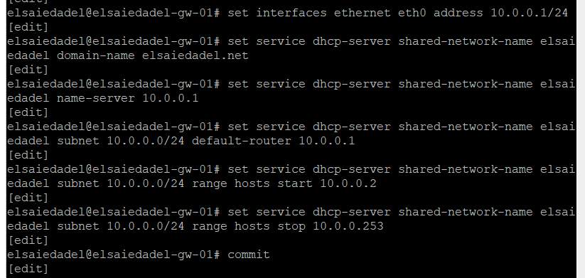

Назначение IPv4-адреса интерфейсу eth0

## Конфигурация DHCP-сервера (IPv4)

- Shared-network: `elsaiedadel`
- Подсеть: `10.0.0.0/24`
- Параметры клиентам:
  - default-router: `10.0.0.1`
  - name-server: `10.0.0.1`
  - domain-name: `elsaiedadel.net`
- Диапазон: `10.0.0.2–10.0.0.253`

[figure not shown]

## Контроль работы DHCP (IPv4)

- Проверка статистики DHCP-сервера
- Подтверждение доступности пула адресов

[figure not shown]

## Получение адреса на PC1 (DHCP)

- Клиент получил:
  - IP: `10.0.0.2/24`
  - GW: `10.0.0.1`
  - DNS: `10.0.0.1`
  - Domain: `elsaiedadel.net`
- Наблюдаются этапы: Discover → Offer → Request → ACK

[figure not shown]

## Проверка конфигурации и связности

- Проверка параметров интерфейса клиента
- Проверка доступности шлюза `10.0.0.1` по ICMP

[figure not shown]

## Журнал DHCP и анализ трафика

- В логах фиксируются события:
  - DHCPDISCOVER / DHCPOFFER / DHCPREQUEST / DHCPACK
- В Wireshark подтверждается обмен DHCP по UDP 67/68 и корректные DHCP-опции

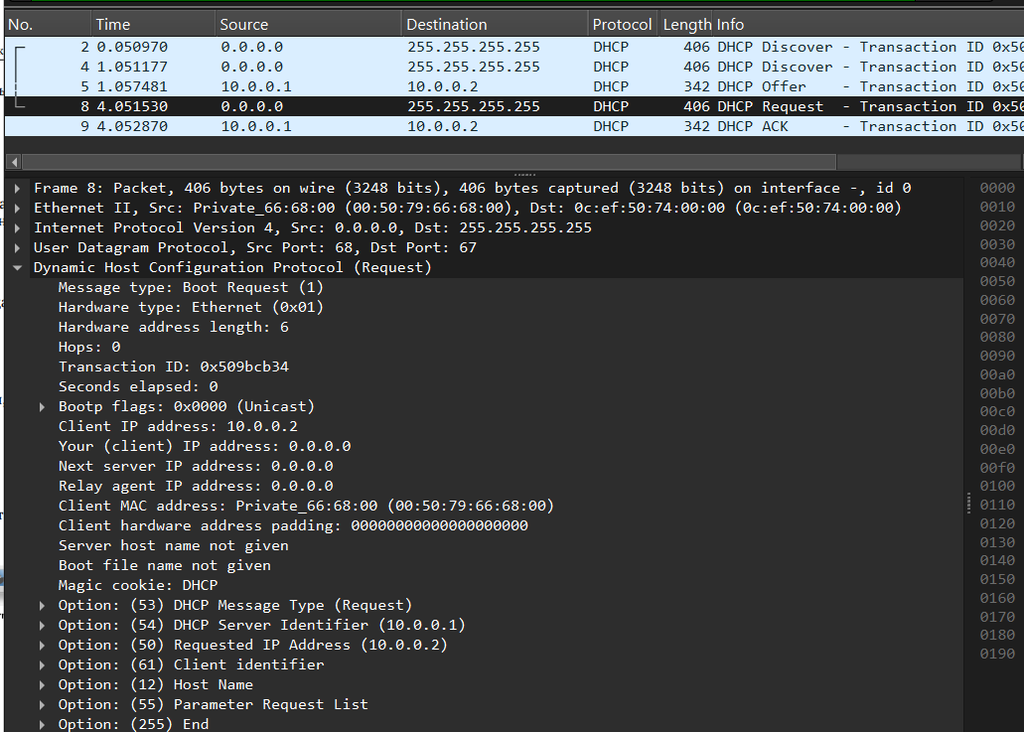

## Топология и захват трафика

- Добавлены сегменты для IPv6:
  - `eth1` → `elsaiedadel-sw-02` → `PC2-elsaiedadel`
  - `eth2` → `elsaiedadel-sw-03` → `PC3-elsaiedadel`
- Для линий `gw-01↔︎sw-02` и `gw-01↔︎sw-03` включён захват трафика

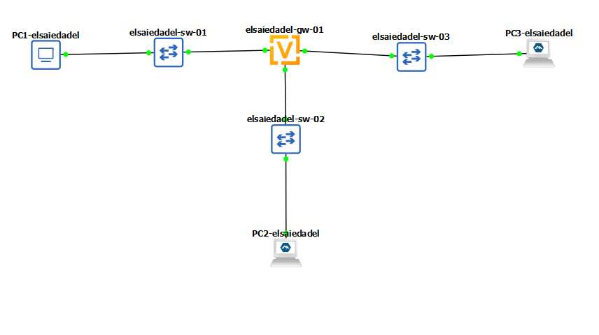

Топология моделируемой сети (IPv6)

## IPv6-адресация на VyOS

- Интерфейсы:
  - `eth1`: `2000::1/64`
  - `eth2`: `2001::1/64`
- Адреса используются как шлюзы для соответствующих сегментов

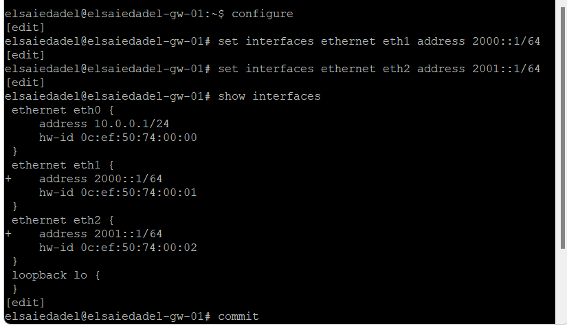

Назначение IPv6-адресов и проверка интерфейсов

## RA + признак «прочих параметров»

- На `eth1` настроены Router Advertisements:
  - prefix: `2000::/64`
  - `other-config-flag`
- Модель:
  - адрес — по **SLAAC**
  - DNS/домен — по **DHCPv6**

[figure not shown]

Настройка RA и DHCPv6 Stateless на eth1

## DHCPv6 Stateless: общие опции

- Shared-network: `elsaiedadel-stateless`
- Common-options:
  - DNS: `2000::1`
  - domain-search: `elsaiedadel.net`
- Подсеть `2000::0/64` используется для привязки сегмента

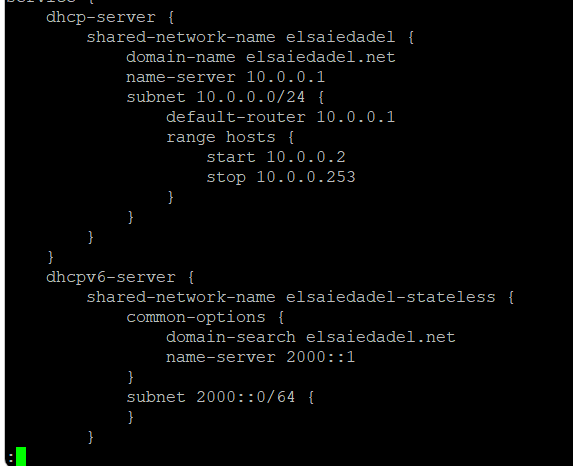

Фрагмент конфигурации DHCPv6 Stateless

## PC2: SLAAC и маршрут по умолчанию

- Получен глобальный адрес из `2000::/64`
- Присутствует default-route через link-local адрес маршрутизатора
- Конфигурация подтверждает работу RA/SLAAC

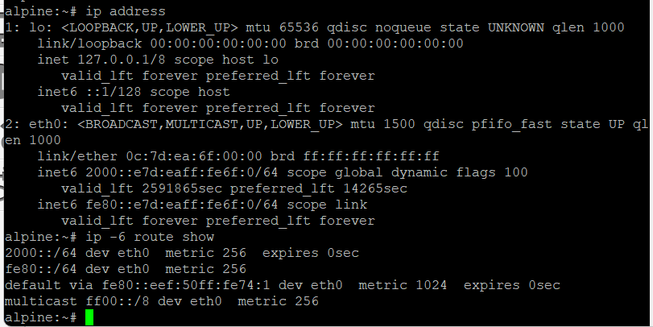

Адресация и маршрутизация PC2

## PC2: проверка связности и DNS

- Проверка ping до `2000::1`
- Проверка DNS в `/etc/resolv.conf`

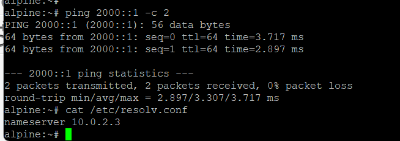

Проверка ping до 2000::1 и DNS на PC2

## Stateless: запрос DHCPv6 «только параметры»

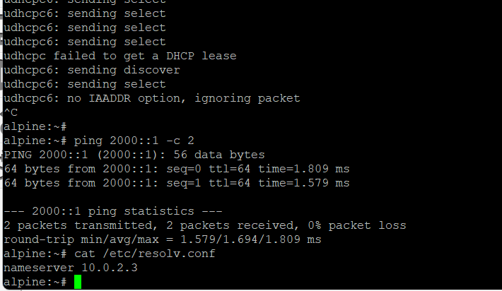

Запрос DHCPv6 параметров на PC2

## DHCPv6 leases для Stateless

- Таблица аренд DHCPv6 пуста
- Это соответствует модели: DHCPv6 не выдаёт IA_NA (адрес), а только опции

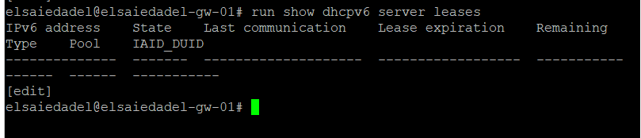

Проверка DHCPv6 leases (Stateless)

## Анализ трафика DHCPv6 (Stateless)

- В трафике фиксируются сообщения:
  - Solicit → Advertise → Request → Reply
- Параметры передаются без выдачи адреса (нет полезной IA_NA)

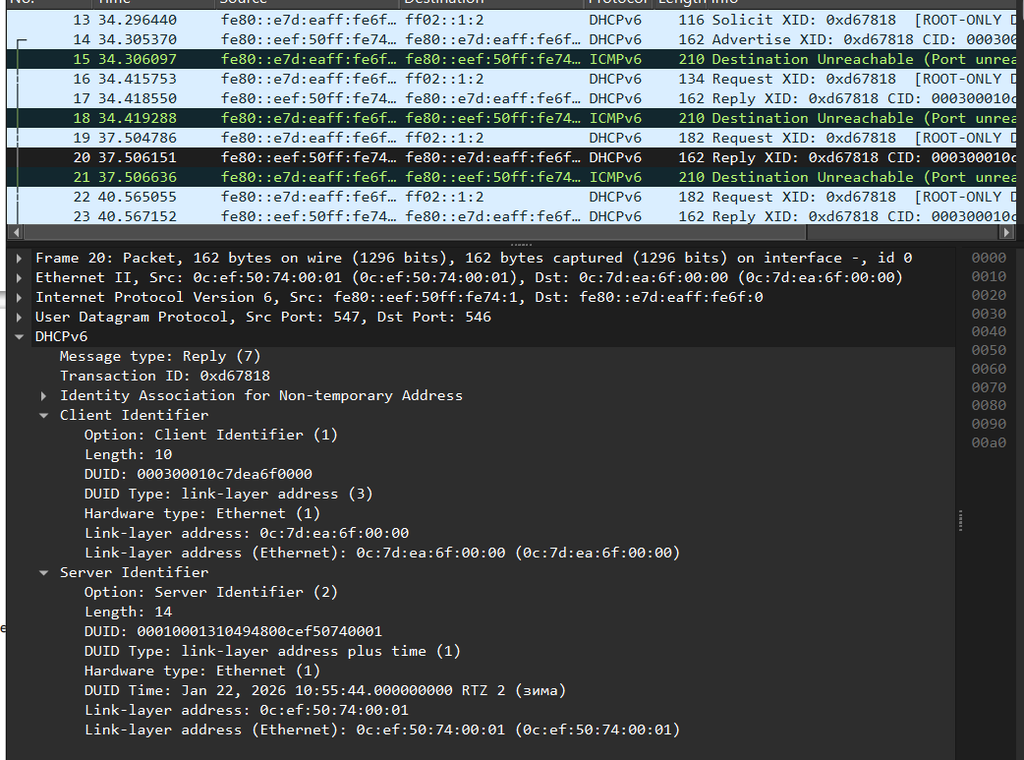

Wireshark: обмен DHCPv6 (Stateless)

## RA с признаком управляемой адресации

- На `eth2` установлен `managed-flag`
- Модель:
  - адрес назначается DHCPv6 (stateful)
  - RA обеспечивает обнаружение маршрутизатора и условия автонастройки

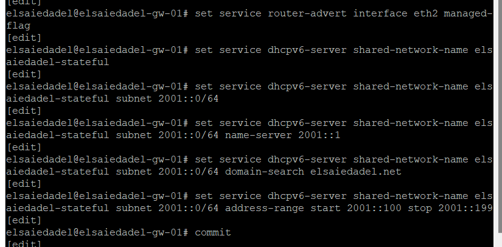

Включение managed-flag на eth2

## DHCPv6 Stateful: подсеть и диапазон

- Shared-network: `elsaiedadel-stateful`
- Подсеть: `2001::0/64`
- Диапазон адресов:
  - `2001::100–2001::199`
- Опции:
  - DNS: `2001::1`
  - domain-search: `elsaiedadel.net`

[figure not shown]

## Контроль DHCPv6 leases (Stateful)

- Зафиксирована активная аренда адреса:
  - `2001::199`
- Отображаются IAID/DUID, время начала и срок аренды

[figure not shown]

## PC3: состояние интерфейса и маршруты

[figure not shown]

## PC3: DNS и проверка связности

- В `/etc/resolv.conf` задано:
  - DNS: `2001::1`
  - search: `elsaiedadel.net`
- Проверка ping до `2001::1`

[figure not shown]

## Анализ трафика DHCPv6 (Stateful)

- Последовательность сообщений:
  - Solicit → Advertise → Request → Reply
- В Reply присутствуют:
  - назначаемый адрес (IA_NA)
  - DNS Recursive Name Server
  - Domain Search List

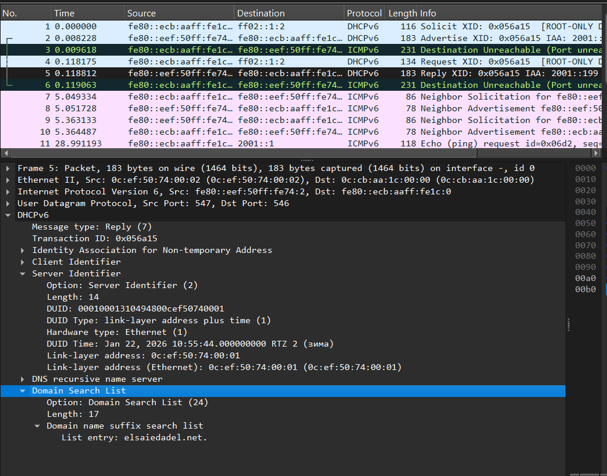

Wireshark: обмен DHCPv6 (Stateful)

# Итоги